# Problem 1 - Simple Lattice Method

# Problem 4 - Washout and Stall Analysis

For this problem we'll be analyzing and comparing a twisted and untwisted wing, to see how it affects the performance of the aircraft close to stall.

Our first step should be to figure out where stall will occur. We plotted our lift curve for the 2D lift conditions, and we can use this to calculate the location of maximum lift and thus the area/angle of attack where stall occurs. Let's reload our polar data and find the stall location. In order to do this, find the angle of attack that corresponds to 2D stall. You've been given the circulation at 0 degrees that can be used to calculate the effective angle of attack. Plot the effective angle of attack over the span of the wing. Then, apply twist to the wing. Wingtwist of 3 degrees means that the airfoil is twisted downward linearly starting from 0 degrees of twist at the root of the wing, and then increasing linearly across the span to 3 degrees of twist at the tip of the wing. You can accomplish this using a linspace.

You've also been provided with the circulation at the stall condition, repeat this process close to stall and apply twist to the wing. Plot both the twisted and untwisted wing and see how they compare close to stall.

```python
def AoA_Calculation(gamma, span, alpha):
    # First, we'll need a variable for integration later/

    #
    nT = len(gT)
    Vinf = 513.333333

    dGamma = np.zeros(nT)
    ai_new = np.zeros(nT)
    ae_new = np.zeros(nT)
    # Here we need to calculate the derivative of circulation with respect to span.
    gamma[0], gamma[-1] = 0, 0

    for i in range(0, nT-1):
        dGamma[i] = (gamma[i+1] - gamma[i])/(span[i+1] - span[i])

    # Now we need to sum the circulation effects by spanwise location:
    for i in range(0, nT):

        integ = np.zeros(nT)

        dy = span[1] - span[0]
        xi = span + dy/2

        for j in range(0, 100):
            integ[j] = dGamma[j] / (span[i] - xi[j])


        J = np.trapz(integ[:-1], xi[:-1])

        # Now that we have calculated J, we can calculate our induced angle of attack
        ai_new[i] = 1/(4*np.pi*Vinf) * J

    ai_new[0] = 2*ai_new[1] - ai_new[2]
    ai_new[-1] = 2*ai_new[-2] - ai_new[-3]


    for i in range(0, 101):
        ae_new[i] = alpha - (ai_new[i] * (180/np.pi))

    coeff = np.polyfit(span, ae_new, 25)
    p = np.poly1d(coeff)
    ae_fin = p(span)

    return ae_fin, ai_new
```

```
(array([187], dtype=int64),)
20.75
```

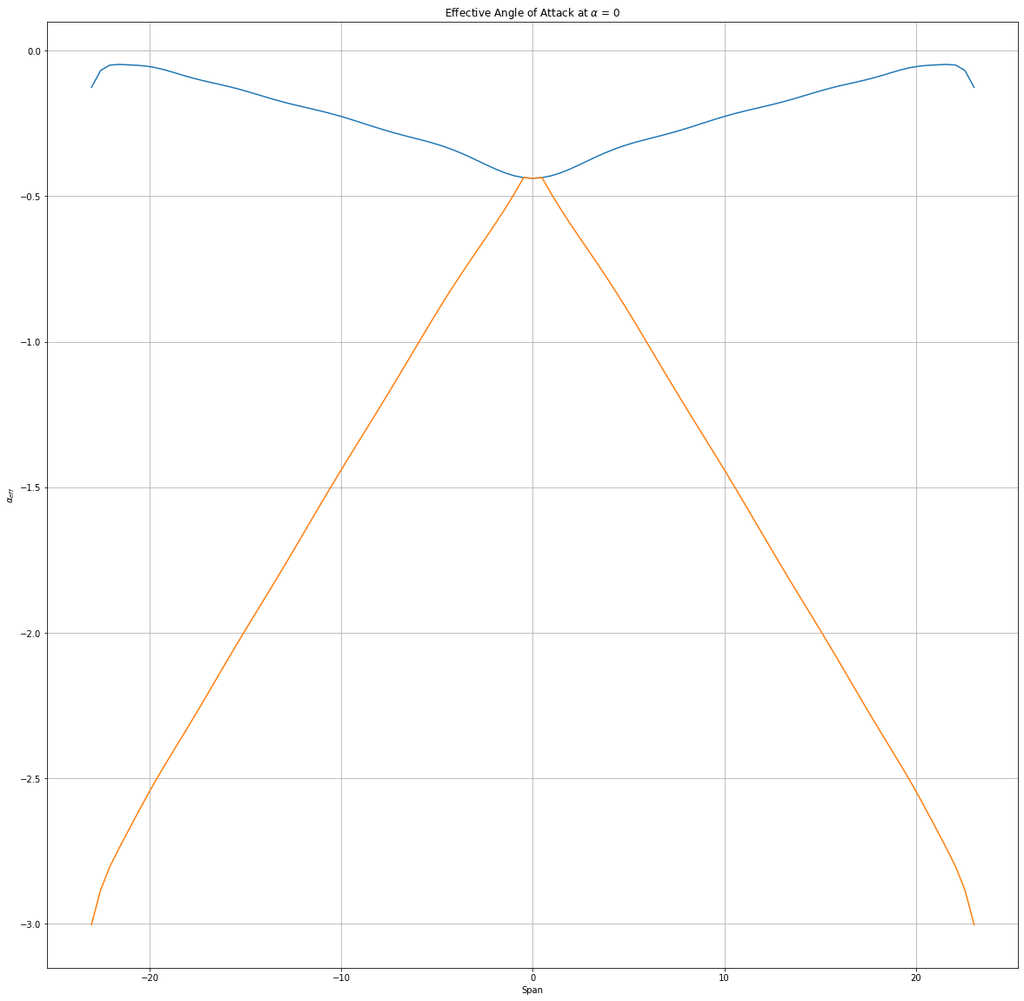

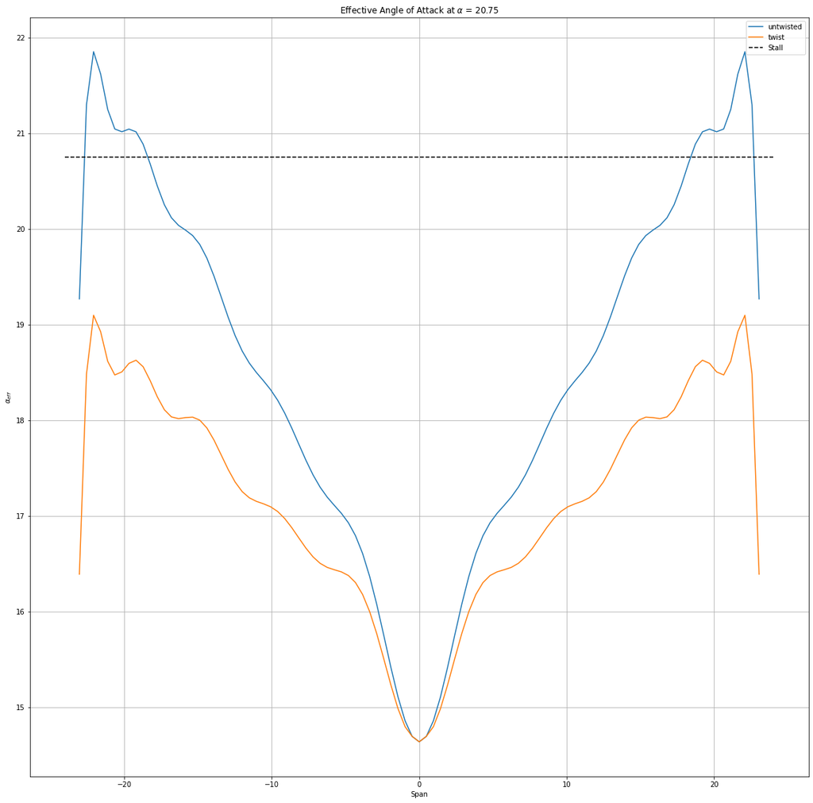

```python
filename = 'p51d.polar.dat'
alpha, Cl, Cd, A, B, C, D = np.loadtxt(filename, skiprows = 12, unpack = True)

# Here, we grab our values from the p51 polar.
# Next, we find the point of stall where Cl is a maximum

a = np.where(Cl == max(Cl))
print(a)
print(alpha[187])

# So here we have the angle of attack of 20.75 where our stall occurs. Now that we know when stall occurs, we should determine the effective angle of attack for our wing.
# We need to set up our wing. Let's determine how our untwisted wing performs at an angle of attack of 0.
# We'll need to run our adjusted equations from above.
# Our goal is to first figure out the effective angle of attack and the induced angle of attack. We're running this at 0 angle of attack and for our trapezoidal wing

filename = 'TrapezoidalCirculation_a0.dat'
span0, gamma0 = np.loadtxt(filename, skiprows = 1, unpack = True)

# Need to calculate the effective angle of attack at 0
alpha_eff0, alpha_ind0 = AoA_Calculation(gamma0, span, 0)

# Now we have our untwisted wing solved at an angle of attack of 0
# Our next step is to apply 3 degrees of twist to the wing.

alpha_untwist = alpha_eff0

twist_array = np.linspace(0, 3, 50)
twist_array2 = np.linspace(3, 0, 50)
zzero = np.array([0])
twist = np.concatenate((twist_array2, zzero, twist_array), axis = 0)

alpha_twist = alpha_eff0 - twist

plt.figure(figsize = (20,20))
plt.title(r'Effective Angle of Attack at $\alpha$ = 0')
plt.plot(sT[2:-2], alpha_untwist[2:-2], label = 'untwisted')
plt.plot(sT[2:-2], alpha_twist[2:-2], label = 'twist')
plt.xlabel('Span')
plt.ylabel(r'$\alpha_{eff}$')
plt.grid(True)
plt.show()

# Here we can see how our wing is slightly twisted down at the wing tips. Neither of these comes close to our stall at alpha = 2-.75
#alpha_eff20, alpha_ind20 = AoA_Calculation(gamma, span, 20.75)

filename = 'TrapezoidalCirculation_a20.dat'
span20, gamma20 = np.loadtxt(filename, skiprows = 1, unpack = True)

# Need to calculate the effective angle of attack at 0
alpha_eff20 , alpha_ind20 = AoA_Calculation(gamma20, span20, 20.75)


wing_twist = alpha_eff20 - twist


plt.figure(figsize = (20,20))
plt.title(r'Effective Angle of Attack at $\alpha$ = 20.75')
plt.plot(sT[2:-2], alpha_eff20[2:-2], label = 'untwisted')
plt.plot(sT[2:-2], wing_twist[2:-2], label = 'twist')
plt.plot(sT, 20.75*np.ones(101), color = 'k', linestyle = '--', label = 'Stall')
plt.xlabel('Span')
plt.ylabel(r'$\alpha_{eff}$')
plt.legend(loc = 'best')
plt.grid(True)
plt.show()
```

After you arrive at the above plot, take some time to think about the difference between the untwisted wing and the twisted wing. When does the untwisted wing reach stall? Which part of the wing will stall first?

[output not shown]

[output cut: 65 more lines]

[output not shown]

[output not shown]

[output not shown]